```python
import rpy2.rinterface
import rpy2.robjects as robjects

import numpy as np
import pandas as pd

import statsmodels.api as sm
import statsmodels.formula.api as smf
from statsmodels.graphics.factorplots import interaction_plot
# https://www.statsmodels.org/stable/examples/notebooks/generated/formulas.html
import seaborn as sns
```

```python
%load_ext rpy2.ipython

sns.set_theme(color_codes=True)
sns.set_context("poster")
```

```python
%%R -o Germany
load('LM3.RData')
```

# Task 1

Specify two models to predict the amount of alcohol consumed on weekends and weekdays by the respondents’education, gender, income,and age.  
Please, use the log of the amount of alcohol.  
Interpret the results(coefficients, R^2).

## Model for weekdays:

```python
modelDays = smf.ols(formula='np.log(alcwkdyn) ~ eduyrsn + gndr + incdec + age',
                    data=Germany).fit()
modelDays.summary()
```

OLS Regression Results

| Dep. Variable: | np.log(alcwkdyn) | R-squared: | 0.048 |
| --- | --- | --- | --- |
| Model: | OLS | Adj. R-squared: | 0.046 |
| Method: | Least Squares | F-statistic: | 25.29 |
| Date: | Сб, 16 янв 2021 | Prob (F-statistic): | 1.85e-20 |
| Time: | 18:18:30 | Log-Likelihood: | -3372.1 |
| No. Observations: | 2000 | AIC: | 6754. |
| Df Residuals: | 1995 | BIC: | 6782. |
| Df Model: | 4 |  |  |
| Covariance Type: | nonrobust |  |  |

|  | coef | std err | t | P>\|t\| | [0.025 | 0.975] |
| --- | --- | --- | --- | --- | --- | --- |
| Intercept | 2.3322 | 0.200 | 11.673 | 0.000 | 1.940 | 2.724 |
| gndr[T.Female] | -0.5492 | 0.059 | -9.291 | 0.000 | -0.665 | -0.433 |
| eduyrsn | 0.0116 | 0.009 | 1.233 | 0.218 | -0.007 | 0.030 |
| incdec | 0.0202 | 0.012 | 1.752 | 0.080 | -0.002 | 0.043 |
| age | 0.0030 | 0.002 | 1.344 | 0.179 | -0.001 | 0.007 |

| Omnibus: | 205.007 | Durbin-Watson: | 1.973 |
| --- | --- | --- | --- |
| Prob(Omnibus): | 0.000 | Jarque-Bera (JB): | 272.041 |
| Skew: | -0.901 | Prob(JB): | 8.45e-60 |
| Kurtosis: | 2.882 | Cond. No. | 328. |

Notes:  
[1] Standard Errors assume that the covariance matrix of the errors is correctly specified.

```python
# Translating from log to percents
print((np.exp(modelDays.params[modelDays.pvalues < 0.05][1:])-1)*100)
```

```
gndr[T.Female]   -42.257076
dtype: float64
```

In the first model for alcohol consumption on `weekdays` only effect of `gender` *is significant*:

- for `Gender`: by `42% less` consumed alcohol for `females`

Overall `prediction power equals to 4.6%` of explained variance which depicts model poorness.

## Model for weekends:

```python
modelEnds = smf.ols(formula='np.log(alcwkndn) ~ eduyrsn + gndr + incdec + age',
                    data=Germany).fit()
modelEnds.summary()
```

OLS Regression Results

| Dep. Variable: | np.log(alcwkndn) | R-squared: | 0.092 |
| --- | --- | --- | --- |
| Model: | OLS | Adj. R-squared: | 0.090 |
| Method: | Least Squares | F-statistic: | 50.33 |
| Date: | Сб, 16 янв 2021 | Prob (F-statistic): | 2.08e-40 |
| Time: | 18:18:30 | Log-Likelihood: | -2904.6 |
| No. Observations: | 1999 | AIC: | 5819. |
| Df Residuals: | 1994 | BIC: | 5847. |
| Df Model: | 4 |  |  |
| Covariance Type: | nonrobust |  |  |

|  | coef | std err | t | P>\|t\| | [0.025 | 0.975] |
| --- | --- | --- | --- | --- | --- | --- |
| Intercept | 3.4394 | 0.158 | 21.738 | 0.000 | 3.129 | 3.750 |
| gndr[T.Female] | -0.5459 | 0.047 | -11.657 | 0.000 | -0.638 | -0.454 |
| eduyrsn | 0.0177 | 0.007 | 2.369 | 0.018 | 0.003 | 0.032 |
| incdec | 0.0099 | 0.009 | 1.081 | 0.280 | -0.008 | 0.028 |
| age | -0.0096 | 0.002 | -5.467 | 0.000 | -0.013 | -0.006 |

| Omnibus: | 438.473 | Durbin-Watson: | 1.996 |
| --- | --- | --- | --- |
| Prob(Omnibus): | 0.000 | Jarque-Bera (JB): | 940.560 |
| Skew: | -1.250 | Prob(JB): | 5.75e-205 |
| Kurtosis: | 5.246 | Cond. No. | 327. |

Notes:  
[1] Standard Errors assume that the covariance matrix of the errors is correctly specified.

```python
# Translating from log to percents
print((np.exp(modelEnds.params[modelEnds.pvalues < 0.05][1:])-1)*100)
```

```
gndr[T.Female]   -42.068734
eduyrsn            1.785707
age               -0.952473
dtype: float64
```

In the second model for alcohol consumption on `weekends` only effect of `Income Decile` *is unsignificant*:

- for `Years of Education`: on `1.7% more` consumed alcohol `per year`
- for `Gender`: same `42% less` consumed alcohol for `females`
- for `Age`: by `~1% less` consumed alcohol `per year`

Overall `prediction power equals to 9%` of explained variance which almost twice as higher than for weekdays model.

# Task 2

Estimate the interaction terms between gender and education and between income and age in both models.  
Interpret the results.

## Model with moderations for weekdays:

```python
modelDaysI = smf.ols(formula='np.log(alcwkdyn) ~ eduyrsn * gndr + incdec * age',
                     data=Germany).fit()
modelDaysI.summary()
```

OLS Regression Results

| Dep. Variable: | np.log(alcwkdyn) | R-squared: | 0.050 |
| --- | --- | --- | --- |
| Model: | OLS | Adj. R-squared: | 0.047 |
| Method: | Least Squares | F-statistic: | 17.32 |
| Date: | Сб, 16 янв 2021 | Prob (F-statistic): | 1.26e-19 |
| Time: | 18:18:30 | Log-Likelihood: | -3370.7 |
| No. Observations: | 2000 | AIC: | 6755. |
| Df Residuals: | 1993 | BIC: | 6795. |
| Df Model: | 6 |  |  |
| Covariance Type: | nonrobust |  |  |

|  | coef | std err | t | P>\|t\| | [0.025 | 0.975] |
| --- | --- | --- | --- | --- | --- | --- |
| Intercept | 2.0834 | 0.311 | 6.706 | 0.000 | 1.474 | 2.693 |
| gndr[T.Female] | -0.7451 | 0.277 | -2.688 | 0.007 | -1.289 | -0.202 |
| eduyrsn | 0.0069 | 0.013 | 0.550 | 0.582 | -0.018 | 0.031 |
| eduyrsn:gndr[T.Female] | 0.0124 | 0.018 | 0.708 | 0.479 | -0.022 | 0.047 |
| incdec | 0.0734 | 0.036 | 2.031 | 0.042 | 0.003 | 0.144 |
| age | 0.0103 | 0.005 | 1.996 | 0.046 | 0.000 | 0.020 |
| incdec:age | -0.0012 | 0.001 | -1.543 | 0.123 | -0.003 | 0.000 |

| Omnibus: | 203.116 | Durbin-Watson: | 1.976 |
| --- | --- | --- | --- |
| Prob(Omnibus): | 0.000 | Jarque-Bera (JB): | 268.868 |
| Skew: | -0.896 | Prob(JB): | 4.13e-59 |
| Kurtosis: | 2.885 | Cond. No. | 3.41e+03 |

Notes:  
[1] Standard Errors assume that the covariance matrix of the errors is correctly specified.  
[2] The condition number is large, 3.41e+03. This might indicate that there are  
strong multicollinearity or other numerical problems.

```python
# Translating from log to percents
print((np.exp(modelDaysI.params[modelDaysI.pvalues < 0.05][1:])-1)*100)
```

```
gndr[T.Female]   -52.532990
incdec             7.620540
age                1.037384
dtype: float64
```

Significant effects on alcohol consumption on weekdays only by `Gender`, `Income Decile` and `Age`:

- for `Gender`: `52% less` consumed alcohol by `females`
- for `Income Decile`: `7% more` per level
- for `Age`: `1% more` per year

The same prediction power as for model without interactions.

## Model with moderations for weekends:

```python
modelEndsI = smf.ols(formula='np.log(alcwkndn) ~ eduyrsn * gndr + incdec * age',
                     data=Germany).fit()
modelEndsI.summary()
```

OLS Regression Results

| Dep. Variable: | np.log(alcwkndn) | R-squared: | 0.097 |
| --- | --- | --- | --- |
| Model: | OLS | Adj. R-squared: | 0.094 |
| Method: | Least Squares | F-statistic: | 35.54 |
| Date: | Сб, 16 янв 2021 | Prob (F-statistic): | 4.79e-41 |
| Time: | 18:18:30 | Log-Likelihood: | -2899.1 |
| No. Observations: | 1999 | AIC: | 5812. |
| Df Residuals: | 1992 | BIC: | 5851. |
| Df Model: | 6 |  |  |
| Covariance Type: | nonrobust |  |  |

|  | coef | std err | t | P>\|t\| | [0.025 | 0.975] |
| --- | --- | --- | --- | --- | --- | --- |
| Intercept | 4.0471 | 0.246 | 16.443 | 0.000 | 3.564 | 4.530 |
| gndr[T.Female] | -0.9995 | 0.219 | -4.554 | 0.000 | -1.430 | -0.569 |
| eduyrsn | 0.0023 | 0.010 | 0.235 | 0.815 | -0.017 | 0.022 |
| eduyrsn:gndr[T.Female] | 0.0298 | 0.014 | 2.141 | 0.032 | 0.003 | 0.057 |
| incdec | -0.0544 | 0.029 | -1.902 | 0.057 | -0.111 | 0.002 |
| age | -0.0181 | 0.004 | -4.406 | 0.000 | -0.026 | -0.010 |
| incdec:age | 0.0015 | 0.001 | 2.411 | 0.016 | 0.000 | 0.003 |

| Omnibus: | 438.934 | Durbin-Watson: | 1.993 |
| --- | --- | --- | --- |
| Prob(Omnibus): | 0.000 | Jarque-Bera (JB): | 949.826 |
| Skew: | -1.247 | Prob(JB): | 5.60e-207 |
| Kurtosis: | 5.278 | Cond. No. | 3.42e+03 |

Notes:  
[1] Standard Errors assume that the covariance matrix of the errors is correctly specified.  
[2] The condition number is large, 3.42e+03. This might indicate that there are  
strong multicollinearity or other numerical problems.

```python
# Translating from log to percents
print((np.exp(modelEndsI.params[modelEndsI.pvalues < 0.05][1:])-1)*100)
```

```
gndr[T.Female]           -63.192093
eduyrsn:gndr[T.Female]     3.020500
age                       -1.793094
incdec:age                 0.154312
dtype: float64
```

Significant effects on alcohol consumption on weekends by `Gender`, `Age` and by both interactions:

- for `Gender`: `63% less` consumed alcohol by `females`
- for `Age`: `1% less` per year

Slightly higher prediction power in comparison with model without interactions.

# Task 3

Visualize the estimated interaction terms and comment on the results.

## For weekdays:

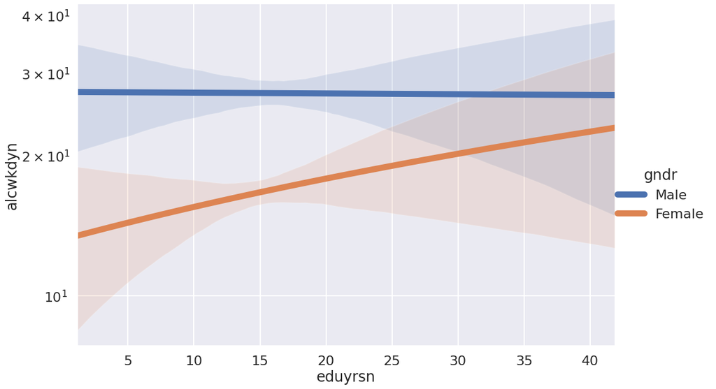

```python
sns.lmplot(x="eduyrsn", y="alcwkdyn", hue="gndr", data=Germany,
           truncate=0, scatter=0, line_kws={'linewidth':10},
           height=9, aspect=12/8).set(yscale="log");
```

### Results unsignificant so there is nothing to interpret.

From `sjPlot.plot_model` [documentation](https://github.com/strengejacke/sjPlot/blob/adf19a793bbf963ab71325b39530bd30736f3c37/R/plot_model.R#L123) on rule for choosing moderator values in non-binary cases (which they based on [this source](https://www.theanalysisfactor.com/3-tips-interpreting-moderation/)):

> [plot_model] uses the `mean value` of the moderator as well as `one standard deviation below and above mean value` to plot the effect of the moderator on the independent variable (following the convention suggested by Cohen and Cohen and popularized by Aiken and West (1991), i.e. using the mean, the value one standard deviation above, and the value one standard deviation below the mean as values of the moderator)

```python
print('Mean - SD: {:.2f}'.format(np.mean(Germany['incdec']) - np.std(Germany['incdec'])))
print('     Mean: {:.2f}'.format(np.mean(Germany['incdec'])))
print('Mean + SD: {:.2f}'.format(np.mean(Germany['incdec']) + np.std(Germany['incdec'])))
```

```
Mean - SD: 3.19
     Mean: 5.97
Mean + SD: 8.75
```

```python
Germany['incdec_mod'] = 'mean'
for i, val in enumerate(Germany['incdec']):
    if val < (np.mean(Germany['incdec']) - np.std(Germany['incdec'])):
        Germany['incdec_mod'].iat[i] = 'mean-sd'
    if val > (np.mean(Germany['incdec']) + np.std(Germany['incdec'])):
        Germany['incdec_mod'].iat[i] = 'mean+sd'
```

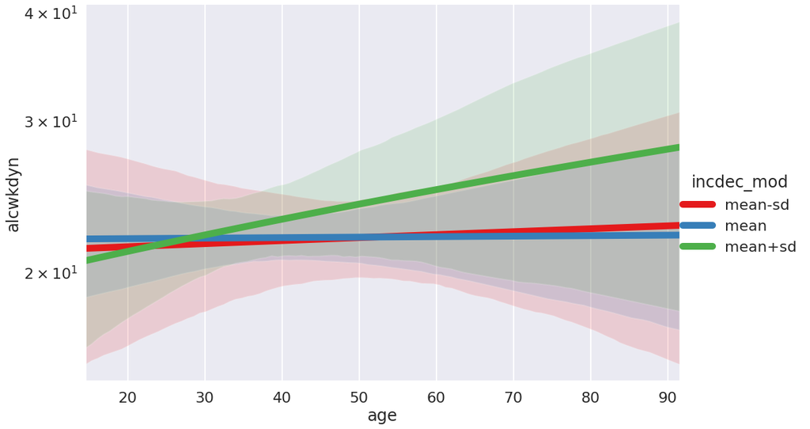

```python
sns.lmplot(x="age", y="alcwkdyn", hue="incdec_mod", data=Germany,
           hue_order=['mean-sd', 'mean', 'mean+sd'],
           truncate=0, scatter=0, line_kws={'linewidth':10}, palette="Set1",
           height=9, aspect=12/8).set(yscale="log");
```

### Results unsignificant so there is nothing to interpret.

## For weekends:

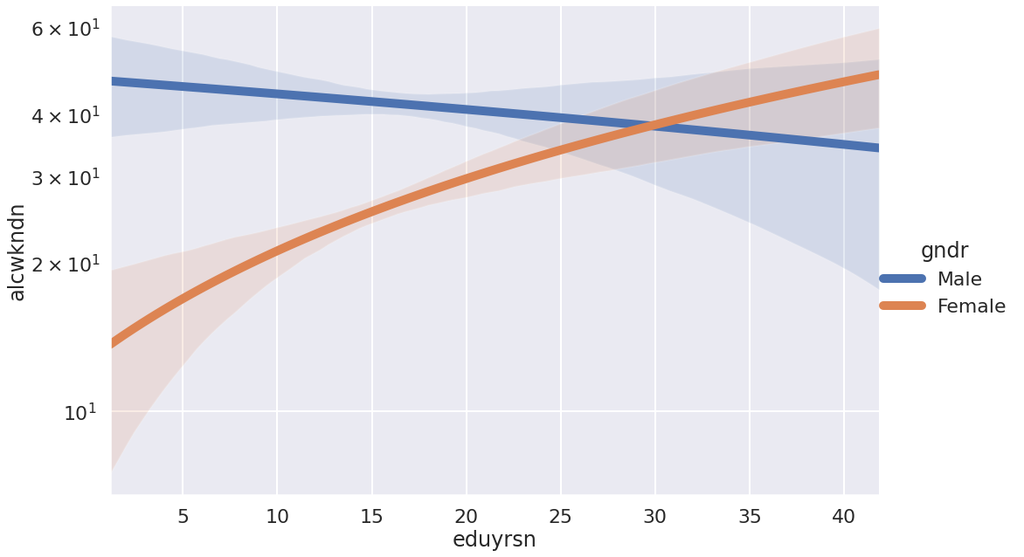

```python
sns.lmplot(x="eduyrsn", y="alcwkndn", hue="gndr", data=Germany,
           truncate=0, scatter=0, line_kws={'linewidth':10},
           height=9, aspect=12/8).set(yscale="log");
```

`Years of Education` have facinating effect on `females` - more educated women tend to consume `more` alcohol comparing with less educated ones.  
At the same time `Years of Education` have opposite effect on `males` *(although less steep)* - more educated men tend to consume `less` alcohol comparing with less educated ones).

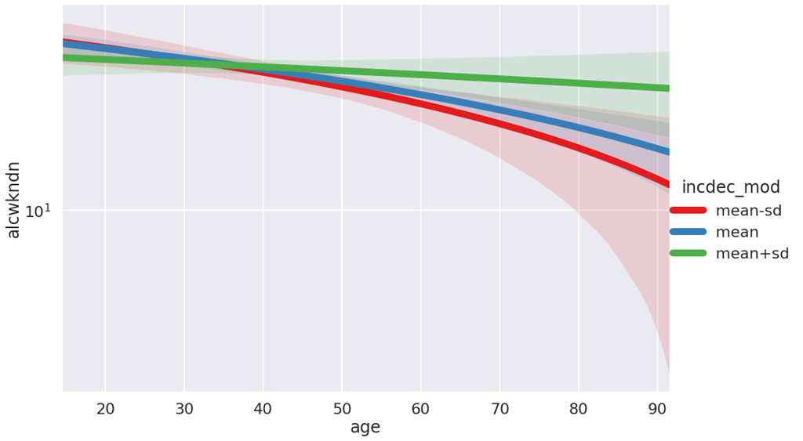

```python
sns.lmplot(x="age", y="alcwkndn", hue="incdec_mod", data=Germany,
           hue_order=['mean-sd', 'mean', 'mean+sd'],
           truncate=0, scatter=0, line_kws={'linewidth':10}, palette="Set1",
           height=9, aspect=12/8).set(yscale="log");
```

`Income Decile` moderates effect of `Age` - for anyone alcohol consumption on weekends will `lower` with higher `Age`, but:

- that negative effect of `Age` is more steep for person with `lower` level of `Income Decile`  
  (i.e. `'lower income'`)
- than for person with `mean` level of `Income Decile`,
- and `Age` is having very little effect on person with `higher` level of `Income Decile`.